# Analysis Plan and EDA

# Libraries

```r
library(tidyverse)
library(skimr)
```

# Analysis Plan

#### Linear Discriminant Analysis

- lower complexity model compared to neural net and random forest - allowing potentially better generalizability.
- low bias, high variance

#### Random Forest

- bagging methodology: random sampling to avoid overfitting
- higher complexity model
- high bias, low variance

#### Neural Net

- high complexity model
- high bias, low variance

# Function Defintions

```r
bool_idx <- function ( to_idx, match){
  # Function takes two vectors and returns boolean index for first vector so you can only keep whats in both.
  # I made this because I couldn't index rows with the columns names it was hard.

  index <-  c()

  # I couldn't figure out how to index columns v rows so this is what I got.
  for (i in to_idx) {

    if (i %in% match){
      index <- c(index,TRUE)
    }
    else {
      index <- c(index,FALSE)
    }
  }

  return(index)
}
```

# Reading in Data

We stored the original and clean versions of the data in the data folder of the project directory.

```r
expression <- as.data.frame((read.table("../data/expression.txt", row.names=1 )))

# Needed as the first two column names start with a number so they get mucked up.
names(expression)[1] <- '184A1'
names(expression)[2] <- '600MPE'

subtypes <- read_delim("../data/subtypes.txt", "\t", escape_double = FALSE, trim_ws = TRUE)

truth_set <-  as.data.frame((read.table("../data/training_set_answers.txt", row.names=1 )))
```

# Preliminary EDA

Our initial EDA will look at the original contents of the given text files.

### Gene Expression Features

We are first going to take a look at the ‘expression.txt’ file. This contains the gene expression data for all the data collected - the mixture of the training and testing sets.

Now I am interested in how many different features present in our dataset.

```r
dim(expression)
```

```
## [1] 18632    39
```

```r
expression %>% head() %>% glimpse()
```

```
## Observations: 6
## Variables: 39
## $ `184A1`     <dbl> 3.219861, 7.766045, 9.667770, 5.363933, 7.686377, ...
## $ `600MPE`    <dbl> 8.463736, 7.959597, 9.939852, 9.835957, 7.645439, ...
## $ AU565       <dbl> 7.935823, 8.073369, 9.817430, 5.696639, 7.761882, ...
## $ BT474       <dbl> 9.010836, 8.120015, 9.533423, 8.155372, 8.393242, ...
## $ CAMA1       <dbl> 7.531960, 7.747369, 9.889735, 6.572890, 7.643172, ...
## $ HCC70       <dbl> 5.048602, 7.708224, 9.496845, 5.386509, 7.409595, ...
## $ HCC1143     <dbl> 3.255517, 7.315066, 10.371671, 5.057817, 8.162389,...
## $ HCC1187     <dbl> 3.673461, 7.201902, 10.352497, 5.343176, 7.882309,...
## $ HCC1395     <dbl> 3.813074, 8.191368, 9.527555, 5.383593, 7.872861, ...
## $ HCC1419     <dbl> 9.681024, 8.424512, 9.569439, 9.669892, 7.147890, ...
## $ HCC1428     <dbl> 6.892229, 7.912665, 9.591158, 6.753368, 8.360774, ...
## $ HCC1806     <dbl> 2.502547, 7.351704, 9.960407, 5.421762, 7.948182, ...
## $ HCC1937     <dbl> 4.701963, 7.592081, 9.405993, 5.185183, 7.969658, ...
```

[output cut: 26 more lines]

There are 18632 distinct features (genes) and 39 observations in the dataset.

```r
expression %>% skim()
```

```
## Skim summary statistics
##  n obs: 18632
##  n variables: 39
##
## -- Variable type:numeric ---------------------------------------------------------------------------------------------------------------------
##     variable missing complete     n mean   sd   p0  p25  p50  p75  p100
##        184A1       0    18632 18632 6.25 1.8  1.33 4.92 6.31 7.54 12.99
##       600MPE       0    18632 18632 6.26 1.83 1.79 4.87 6.32 7.6  13.34
##        AU565       0    18632 18632 6.28 1.81 1.57 4.88 6.27 7.61 12.94
##        BT474       0    18632 18632 6.27 1.85 1.55 4.85 6.3  7.62 12.79
##        BT549       0    18632 18632 6.27 1.83 1.59 4.85 6.29 7.61 13.11
##        CAMA1       0    18632 18632 6.27 1.89 1.69 4.75 6.33 7.69 12.8
##      HCC1143       0    18632 18632 6.23 1.86 1.5  4.8  6.28 7.57 12.71
##      HCC1187       0    18632 18632 6.26 1.8  1.45 4.9  6.28 7.57 12.76
##      HCC1395       0    18632 18632 6.27 1.79 1.62 4.88 6.28 7.56 12.87
##      HCC1419       0    18632 18632 6.25 1.91 1.65 4.72 6.28 7.65 13.01
##      HCC1428       0    18632 18632 6.26 1.86 1.37 4.8  6.3  7.65 12.83
##      HCC1806       0    18632 18632 6.33 1.77 1.59 5.01 6.34 7.56 13.01
##      HCC1937       0    18632 18632 6.27 1.87 1.63 4.83 6.32 7.64 12.99
##      HCC1954       0    18632 18632 6.27 1.82 1.6  4.87 6.3  7.59 13.08
##      HCC2185       0    18632 18632 6.31 1.76 1.82 4.95 6.34 7.57 12.68
##      HCC3153       0    18632 18632 6.28 1.79 1.73 4.93 6.29 7.58 13.02
##        HCC70       0    18632 18632 6.31 1.75 1.84 5.01 6.34 7.56 13.08
##       HS578T       0    18632 18632 6.24 1.82 1.7  4.84 6.23 7.57 13.17
##          LY2       0    18632 18632 6.33 1.74 1.7  5.02 6.37 7.57 12.69
##       MCF10A       0    18632 18632 6.28 1.77 1.54 4.93 6.3  7.56 13.26
##       MCF10F       0    18632 18632 6.24 1.81 1.66 4.85 6.26 7.56 12.99
##       MCF12A       0    18632 18632 6.29 1.8  1.66 4.92 6.29 7.58 13.3
##         MCF7       0    18632 18632 6.32 1.75 1.47 5.02 6.34 7.57 12.85
##   MDAMB134VI       0    18632 18632 6.28 1.79 1.64 4.9  6.37 7.57 12.67
##     MDAMB157       0    18632 18632 6.25 1.86 1.5  4.86 6.29 7.58 13.27
##  MDAMB175VII       0    18632 18632 6.34 1.69 1.75 5.09 6.36 7.54 13.92
##     MDAMB231       0    18632 18632 6.27 1.81 1.56 4.9  6.27 7.6  13.3
##     MDAMB361       0    18632 18632 6.25 1.86 1.45 4.83 6.28 7.59 12.93
##     MDAMB415       0    18632 18632 6.26 1.84 1.63 4.83 6.32 7.59 13.39
##     MDAMB453       0    18632 18632 6.42 1.61 1.8  5.25 6.4  7.53 12.69
##        SKBR3       0    18632 18632 6.33 1.74 1.57 5.01 6.3  7.58 13.09
##   SUM1315MO2       0    18632 18632 6.28 1.77 1.72 4.96 6.31 7.55 13.02
##     SUM149PT       0    18632 18632 6.33 1.7  1.42 5.08 6.38 7.53 13.05
##     SUM159PT       0    18632 18632 6.29 1.77 1.45 4.93 6.29 7.56 13.05
```

[output cut: 30 more lines]

```
##  ▁▅▇▇▆▂▁▁
##  ▁▅▇▇▅▁▁▁
##  ▁▅▇▇▆▂▁▁
##  ▁▅▇▇▇▂▁▁
##  ▁▅▇▇▆▂▁▁
##  ▁▃▆▇▆▂▁▁
##  ▁▅▇▇▆▂▁▁
##  ▁▅▇▇▆▂▁▁
##  ▁▃▆▇▆▂▁▁
##  ▁▅▇▇▆▂▁▁
##  ▁▅▇▇▆▂▁▁
##  ▁▃▆▇▅▁▁▁
##  ▁▅▆▇▆▂▁▁
##  ▁▅▇▇▆▂▁▁
##  ▁▅▇▇▆▂▁▁
```

Looking at the raw expression data it is clear that it is raw data that has not been normalized yet. Normalization technqiues will be applied to the data dependent on which model we intend to use if the model requires that assumption of normalization.

There is also no missingness in the orginal gene expression data from skimming the data. The means of the differnt observations are about the same and they each have similar distributions based on the histogram.

Each observation is the the cell type which will allow us to extrapolate to each cell type response to the approprate drug treatment. Additonally each gene expression feature is annotated with the gene or region name that gives us meaninful information.

### Cell Types

We will look at the subtypes as well as all the truth set.

```r
subtypes %>% glimpse()
```

```
## Observations: 39
## Variables: 2
## $ cellline <chr> "184A1", "600MPE", "AU565", "BT474", "BT549", "CAMA1"...
## $ subtype  <chr> "Normal-like", "Luminal", "Luminal", "Luminal", "Clau...
```

```r
subtypes %>% distinct(subtype)
```

```
## # A tibble: 4 x 1
##   subtype
##   <chr>
## 1 Normal-like
## 2 Luminal
## 3 Claudin-low
## 4 Basal
```

This dataset linked the cell lines to their subtype distinction. Each observation is a unique instance of cell line name with its corresponding subtype classification.

> Thus, our model must be generalizable to predict drug response with cell subtypes that it has not been trained on.

```r
head(truth_set,5)
```

```
##         CGC.11047 Carboplatin Cisplatin GSK1070916 GSK1120212 GSK461364
## CAMA1           0           0         0          0          0         0
## ZR751           0           0         0          0          0         0
## HCC1419         1           0         0          0          1         0
## 184A1           0           1         1          1          1         0
## HCC1428         0           0         0          0          0         0
##         Geldanamycin Oxaliplatin PF.3084014 PF.3814735 PF.4691502
## CAMA1              0           0          0          0          0
## ZR751              0           1          1          0          1
## HCC1419            0           0          0          0          1
## 184A1              1           1          1          0          1
## HCC1428            0           0          0          0          0
##         Paclitaxel
## CAMA1            1
## ZR751            0
## HCC1419          0
## 184A1            0
## HCC1428          0
```

```r
dim(truth_set)
```

```
## [1] 25 12
```

```r
names(truth_set) # Show all the drugs were in study
```

```
##  [1] "CGC.11047"    "Carboplatin"  "Cisplatin"    "GSK1070916"
##  [5] "GSK1120212"   "GSK461364"    "Geldanamycin" "Oxaliplatin"
##  [9] "PF.3084014"   "PF.3814735"   "PF.4691502"   "Paclitaxel"
```

We can observe that we are predict drug responsivenes to 25 cell lines to 12 different drugs. Names are present in the above output.

Since, there are only 25 cell lines present in our training truth set, we will only build our model to predect these 25 cell lines with known outcomes. This must be done as we do not have outcomes for these cell lines outside of this truth set. I will remove the cell lines not in the expression set.

## Processing the Clean Data set

Use the truth_set (cell lines with known outcomes only) to create a vector to decide if the expression set data is kept for training. The rest are the test dataset used to generate a prediction matrix.

```r
full <- names(expression) # ALL observations in the given expression dataset
truth_name <- rownames(truth_set) # observations with known outcomes (based on the truth set)
exp_idx <- bool_idx(full,truth_name) # create indices

train_expr <- expression[,exp_idx] # Pyll out the new expression set with only observations that have a known outcome
dim(train_expr) # Check the dimensions
```

```
## [1] 18632    25
```

```r
# I will also seperate the subtypes this way. This way we are only looking at the cell lines with known outcomes
sub_names <- subtypes %>% pull(cellline)
sub_idx <- bool_idx(sub_names,truth_name)
train_subs <- subtypes[sub_idx,]
dim(train_subs)
```

```
## [1] 25  2
```

Now I will subset the test data use the boolean indexes I generated in the last codeblock.

```r
test_expr <- expression[,!exp_idx]
test_subs <- subtypes[!sub_idx,]

dim(test_expr)
```

```
## [1] 18632    14
```

```r
dim(test_subs)
```

```
## [1] 14  2
```

Originally only 24 samples were retained but upon futher investiagtion there was an X in front of all cellines with integers as the first character. Only 184A1 is present in the truth set but does not have corresponding expression data.

> All 25 cell lines from the truth set were present in the training data. Subtypes were also seperated the same way.

Here is the raw data showing what happened.

```r
full <- names(as.data.frame((read.table("../data/expression.txt", row.names=1 ))))
truth <- rownames(truth_set)

# I couldn't figure out how to index columns vs rows so this is what I got.
for (t in truth) {
  if (t %in% full){
    # pass
  }
  else {
    print(t)
  }
}
```

```
## [1] "184A1"
```

Now we will seperate the data into a tab seperated file for each of the 3 input datasets.

Note: the truth set does not need to be modified as it includes all of the cell lines with known outcomes on drug responsiveness.

## Sorting Cleaned Data

Now that we have the clean subsectioned data we will want to make sure that the cell lines match across all tables.

```r
# Sort train expression
train_expr <- with(train_expr,  train_expr[ , order(names(train_expr))])

# Sort train subtype
train_subs <- with(train_subs,  train_subs[order(cellline) , ])

# Sort truth
truth_set <- with(truth_set,  truth_set[order(rownames(truth_set)) , ])


##    Testing feature set
# Sort test expression data
test_expr <- with(test_expr,  test_expr[ , order(names(test_expr))])

# Sort test subtypes
test_subs <- with(test_subs,  test_subs[order(cellline) , ])



# Check to make sure all cellines match
names(train_expr)
```

```
##  [1] "184A1"       "BT474"       "CAMA1"       "HCC1143"     "HCC1395"
##  [6] "HCC1419"     "HCC1428"     "HCC1806"     "HCC1937"     "HCC2185"
## [11] "HCC70"       "HS578T"      "MCF10F"      "MDAMB134VI"  "MDAMB175VII"
## [16] "MDAMB415"    "MDAMB453"    "SUM1315MO2"  "SUM149PT"    "SUM159PT"
## [21] "SUM185PE"    "SUM52PE"     "T47D"        "ZR751"       "ZR75B"
```

```r
train_subs %>% pull(cellline)
```

```
##  [1] "184A1"       "BT474"       "CAMA1"       "HCC1143"     "HCC1395"
##  [6] "HCC1419"     "HCC1428"     "HCC1806"     "HCC1937"     "HCC2185"
## [11] "HCC70"       "HS578T"      "MCF10F"      "MDAMB134VI"  "MDAMB175VII"
## [16] "MDAMB415"    "MDAMB453"    "SUM1315MO2"  "SUM149PT"    "SUM159PT"
## [21] "SUM185PE"    "SUM52PE"     "T47D"        "ZR751"       "ZR75B"
```

```r
rownames(truth_set)
```

```
##  [1] "184A1"       "BT474"       "CAMA1"       "HCC1143"     "HCC1395"
##  [6] "HCC1419"     "HCC1428"     "HCC1806"     "HCC1937"     "HCC2185"
## [11] "HCC70"       "HS578T"      "MCF10F"      "MDAMB134VI"  "MDAMB175VII"
## [16] "MDAMB415"    "MDAMB453"    "SUM1315MO2"  "SUM149PT"    "SUM159PT"
## [21] "SUM185PE"    "SUM52PE"     "T47D"        "ZR751"       "ZR75B"
```

```r
names(test_expr)
```

```
##  [1] "600MPE"   "AU565"    "BT549"    "HCC1187"  "HCC1954"  "HCC3153"
##  [7] "LY2"      "MCF10A"   "MCF12A"   "MCF7"     "MDAMB157" "MDAMB231"
## [13] "MDAMB361" "SKBR3"
```

```r
test_subs %>% pull(cellline)
```

```
##  [1] "600MPE"   "AU565"    "BT549"    "HCC1187"  "HCC1954"  "HCC3153"
##  [7] "LY2"      "MCF10A"   "MCF12A"   "MCF7"     "MDAMB157" "MDAMB231"
## [13] "MDAMB361" "SKBR3"
```

```r
# Double check all the dataframs have correct observations via the dimensions
dim(train_expr)
```

```
## [1] 18632    25
```

```r
dim(train_subs)
```

```
## [1] 25  2
```

```r
dim(truth_set)
```

```
## [1] 25 12
```

```r
# Write expression
write.table(train_expr, file= '../data/clean_expression.txt', sep= '\t', na = 'NA')
# Write subtypes
write_tsv(train_subs, '../data/clean_subtypes.txt', na = "NA")
# Write training set answers
write.table(truth_set, '../data/clean_training_answers.txt', sep= '\t', na = "NA")
```

```r
# Double check all the dataframs have correct observations via the dimensions
dim(test_expr)
```

```
## [1] 18632    14
```

```r
dim(test_subs)
```

```
## [1] 14  2
```

```r
# Write expression
write.table(test_expr, file= '../data/clean_test_expression.txt', sep= '\t', na = 'NA')
# Write subtypes
write_tsv(test_subs, '../data/clean_test_subtypes.txt', na = "NA")



### Reading in the data:
test_expr <- as.data.frame((read.table("../data/clean_test_expression.txt", row.names=1 )))
rownames(expression)[1] <- '184A1'# Rename the only integer name

# Read in the subtype data
test_subs <- read_tsv("../data/clean_test_subtypes.txt")
```

We checked the dimensions of the edited files to make sure that we only captured the cell lines with known drug responses to build our classifier. There should be only 25 observations, which we see. This means that we subsectioned out data correctly so we wrote it out to new files to build our classifier

# New Import Commands

```r
# Read in the cleaned expression data
# NOTE: data has features are ROWS when reading it from the flat file.
expression <- as.data.frame((read.table("../data/clean_expression.txt", row.names=1 )))
rownames(expression)[1] <- '184A1'# Rename the only integer name

# Read in the subtype data
subtypes <- read_tsv("../data/clean_subtypes.txt")

# Read in the truth set
truth_set <-  as.data.frame((read.table("../data/clean_training_answers.txt", row.names=1 )))


# Create merged feature set
featureSet<-cbind(subtypes[,2],t(expression))

dim(expression)
```

```
## [1] 18632    25
```

```r
dim(subtypes)
```

```
## [1] 25  2
```

```r
dim(truth_set)
```

```
## [1] 25 12
```

```r
dim(featureSet)
```

```
## [1]    25 18633
```

# Extended EDA on Cleaned Data

### Subtype by Cell line

```r
featureSet %>% count(subtype)
```

```
## # A tibble: 4 x 2
##   subtype         n
##   <chr>       <int>
## 1 Basal           5
## 2 Claudin-low     4
## 3 Luminal        14
## 4 Normal-like     2
```

```r
featureSet%>% filter(subtype=='Normal-like')
```

[output not shown]

[output cut: 7013 more lines]

[output not shown]

The number of observations for each subtype is heavily skewed. With the data we are given we would probably have better predictive power with determining the drug response for luminal subtypes (n=14), but the other subtypes only have 2 to 5 observations which is not that much data in each group. It will probably make our data anlysis harder because in the paper, the authors said that the cell line subtype created a decent naive model, but adding in transcriptome data gave the model more power to better predict drug responsiveness.

Based on this given information, it would be a good idea to include the subtype as a feature in the model, especially with LDA where determining which features is an important aspect of the method.

### Variance in the data

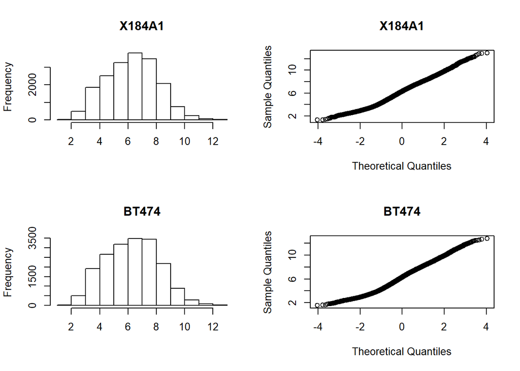

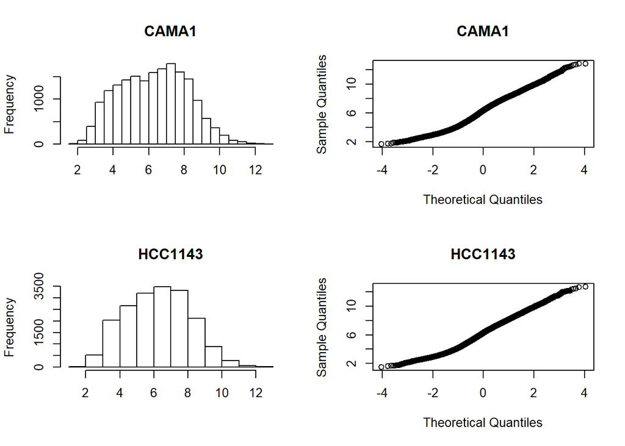

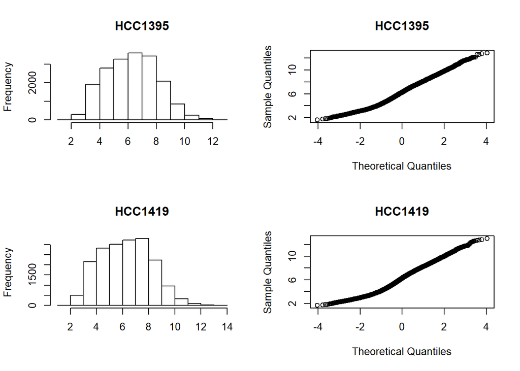

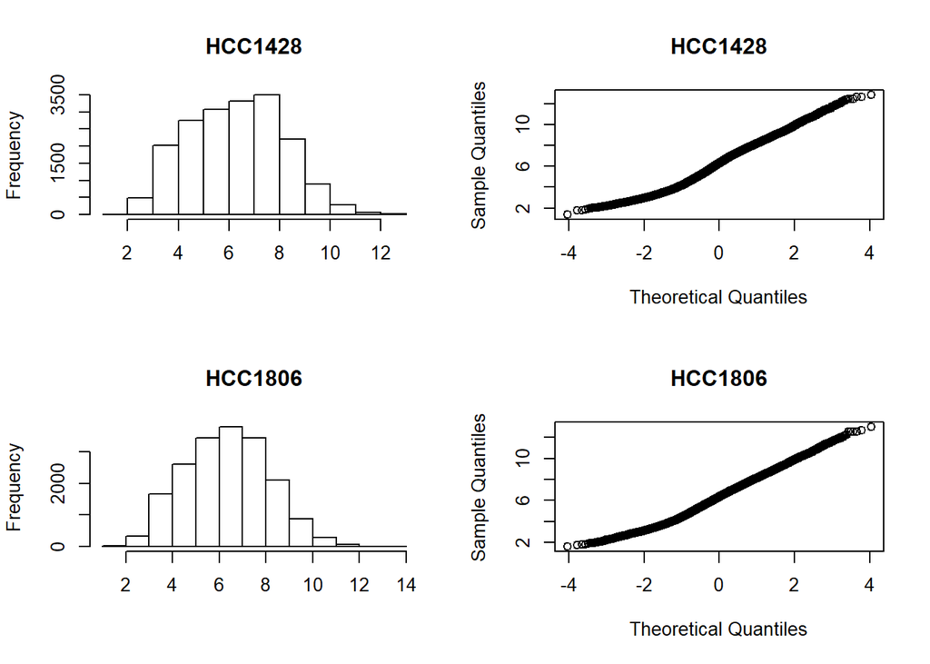

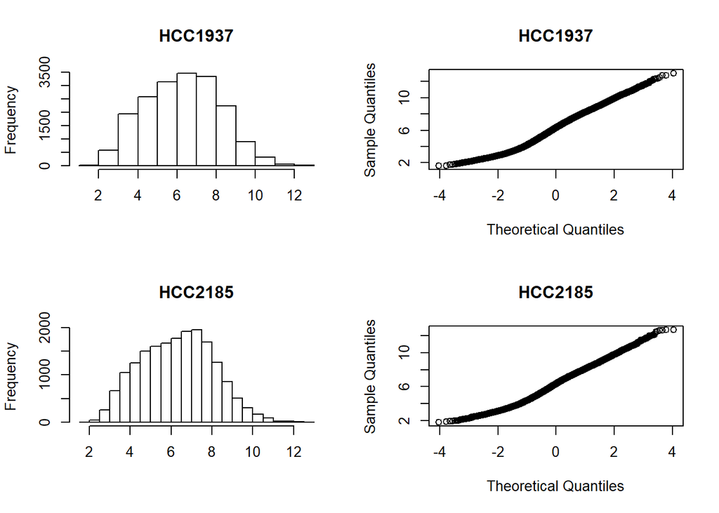

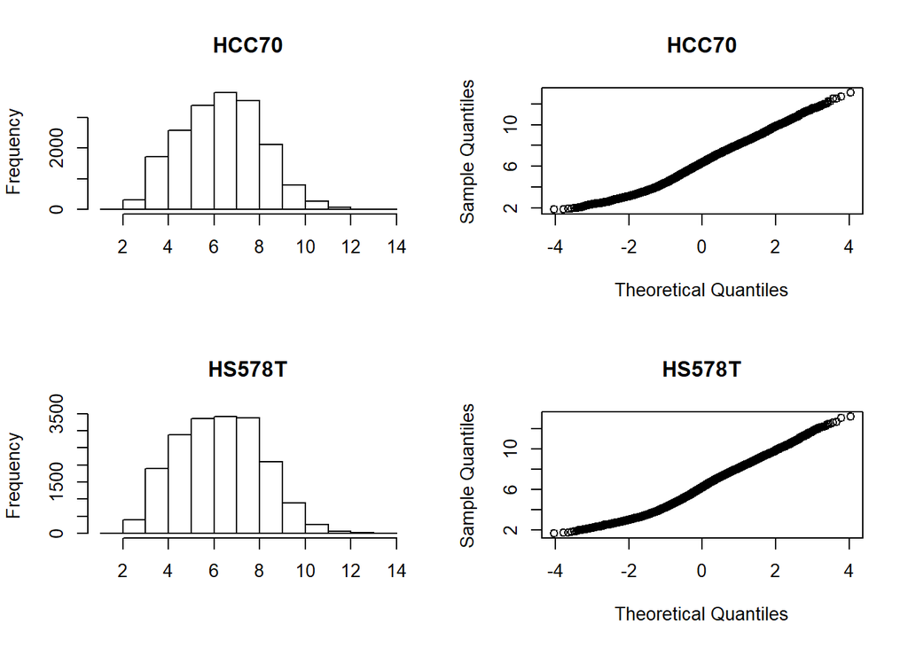

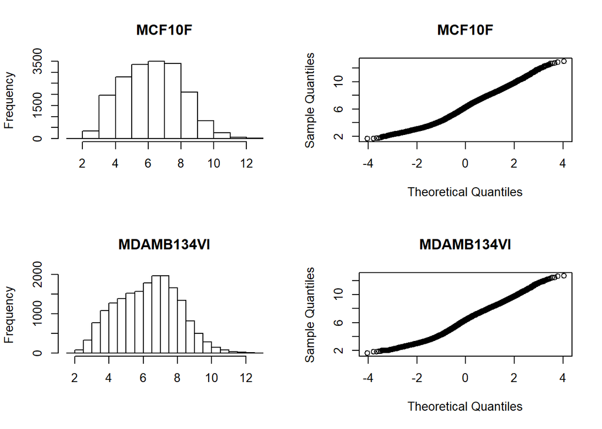

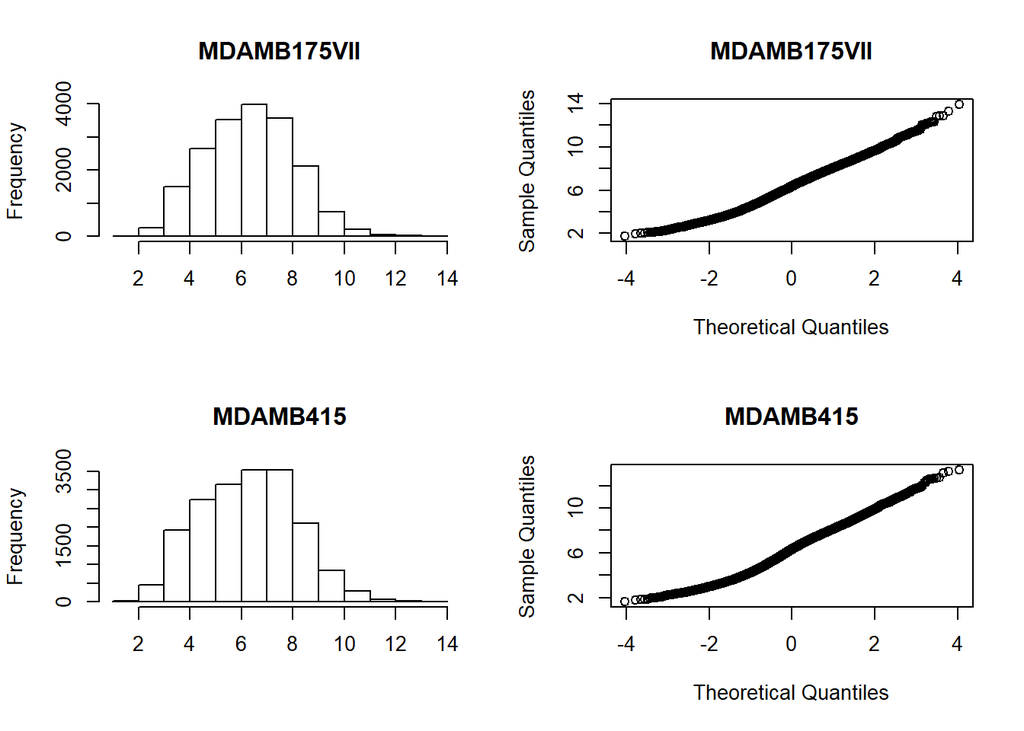

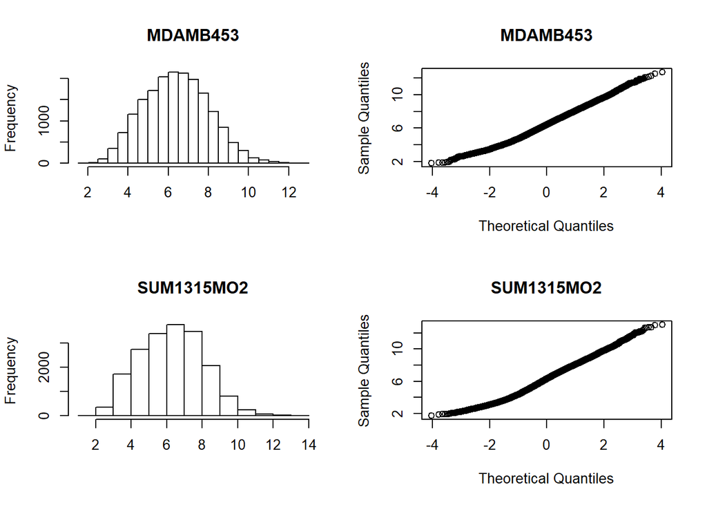

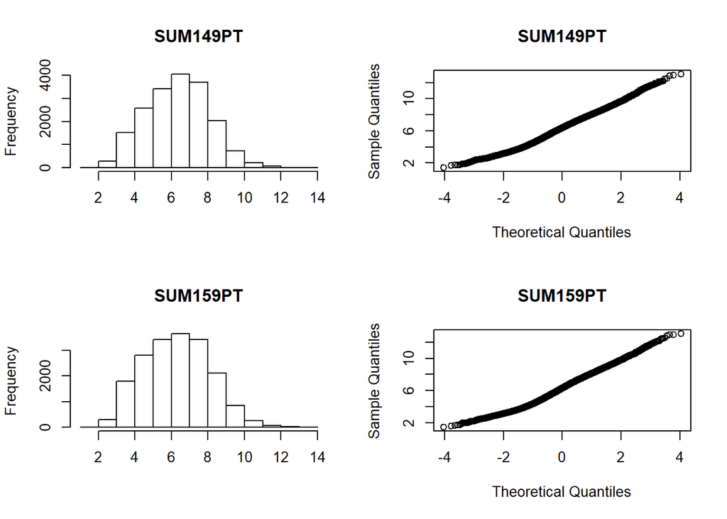

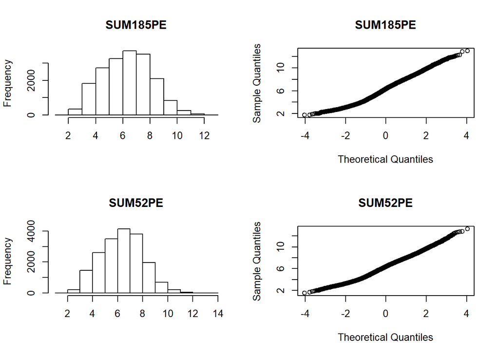

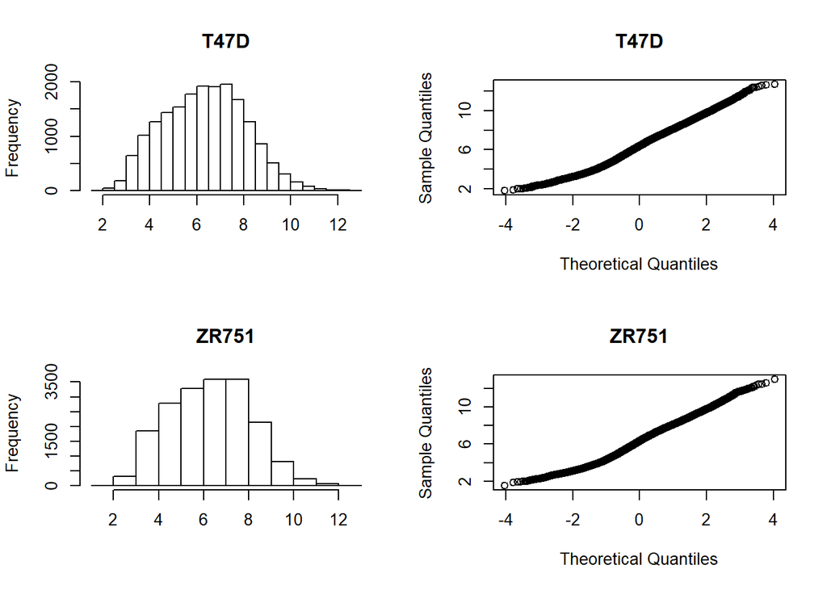

[1 more figures not shown]

```r
observ <- (colnames(expression))

par(mfrow=c(2,2))
for (i in 1:length(observ)){
  hist(expression[,i], main = observ[i], xlab='')
  qqnorm(expression[,i], main=observ[i])
}
```

We can see that most of the gene expression data for each training observation is normal after calling the q-q plots. We will not normalize the data because it is close enough to normal (for the parametric models like LDA).